# Generalised linear models with R

A short introduction for a 1–2 hour practical

O Rodriguez de Rivera Ortega, PhD

University of Exeter

# 1 Session overview

## 1.1 Learning outcomes

By the end of this short practical, students should be able to:

- explain why ordinary linear regression is not suitable for binary or count responses;
- identify the three main parts of a GLM: **random component**, **linear predictor** and **link function**;
- fit a GLM in R using `glm()`;
- interpret model coefficients on the **link scale** and the **response scale**;
- obtain predictions, confidence intervals and simple diagnostic plots.

# 2 Setup

## 2.1 Packages used

Run once before the session if packages are not installed.

```r
install.packages(c("tidyverse", "palmerpenguins", "MASS", "pROC"))
```

The main examples use package or built-in datasets, so the session does not depend on fragile online CSV links.

```r
library(tidyverse)
library(palmerpenguins)

theme_set(theme_minimal(base_size = 12))
```

# 3 From linear models to GLMs

## 3.1 Why do we need GLMs?

The ordinary linear model is useful when the response is approximately continuous and Normally distributed:

$$Y_i = \beta_0 + \beta_1 x_{1i} + \cdots
+ \beta_p x_{pi} + \varepsilon_i, \qquad \varepsilon_i \sim N(0,
\sigma^2).$$

However, many scientific responses are not continuous Normal variables:

- **binary data:** presence/absence, alive/dead, yes/no;
- **counts:** number of individuals, disease cases, defects, events;
- **positive skewed data:** waiting times, biomass, concentrations.

Problems with using `lm()` for these responses:

- predictions can fall outside the possible range;
- the variance often changes with the mean;
- the Normal error assumption is inappropriate.

## 3.2 What is a GLM?

A GLM has three ingredients.

1. **Random component:** a distribution for the response, e.g. Binomial or Poisson.
2. **Linear predictor:**

$$\eta_i = \beta_0 + \beta_1 x_{1i} +
\cdots + \beta_p x_{pi}.$$

3. **Link function:** a function connecting the mean response to the linear predictor:

$$g(\mu_i) = \eta_i, \qquad \mu_i =
E(Y_i).$$

The link lets us keep a linear model structure while respecting the range of the response.

## 3.3 Common GLMs

| Response type | Distribution | Link | R family |
| --- | --- | --- | --- |
| Continuous Normal | Normal | Identity | `gaussian()` |
| Binary 0/1 | Binomial | Logit | `binomial()` |
| Counts | Poisson | Log | `poisson()` |
| Counts with overdispersion | Negative binomial | Log | `MASS::glm.nb()` |

## 3.4 The `glm()` function

The syntax is very similar to `lm()`:

```r
glm(response ~ predictor1 + predictor2,
    family = binomial(link = "logit"),
    data = my_data)
```

Important arguments:

- `formula`: model structure, as in `lm()`;
- `family`: distribution and link;
- `data`: data frame containing the variables.

Important functions:

```r
summary(model)          # coefficient table and model fit
coef(model)             # estimated coefficients
fitted(model)           # fitted means on the response scale
predict(model)          # predictions on the link scale by default
predict(model, type = "response")
residuals(model, type = "pearson")
AIC(model)
```

# 4 A Gaussian GLM example

## 4.1 Clean the penguin data

Before moving to binary and count responses, we can show that a Gaussian GLM with identity link is equivalent to a linear model.

```r
penguins_clean <- penguins %>%
  drop_na(species, flipper_length_mm, body_mass_g, sex)

glimpse(penguins_clean)
```

```
## Rows: 333
## Columns: 8
## $ species           <fct> Adelie, Adelie, Adelie, Adelie, Adelie, Adelie, Adel…
## $ island            <fct> Torgersen, Torgersen, Torgersen, Torgersen, Torgerse…
## $ bill_length_mm    <dbl> 39.1, 39.5, 40.3, 36.7, 39.3, 38.9, 39.2, 41.1, 38.6…
## $ bill_depth_mm     <dbl> 18.7, 17.4, 18.0, 19.3, 20.6, 17.8, 19.6, 17.6, 21.2…
## $ flipper_length_mm <int> 181, 186, 195, 193, 190, 181, 195, 182, 191, 198, 18…
## $ body_mass_g       <int> 3750, 3800, 3250, 3450, 3650, 3625, 4675, 3200, 3800…
## $ sex               <fct> male, female, female, female, male, female, male, fe…
## $ year              <int> 2007, 2007, 2007, 2007, 2007, 2007, 2007, 2007, 2007…
```

## 4.2 Plot the relationship

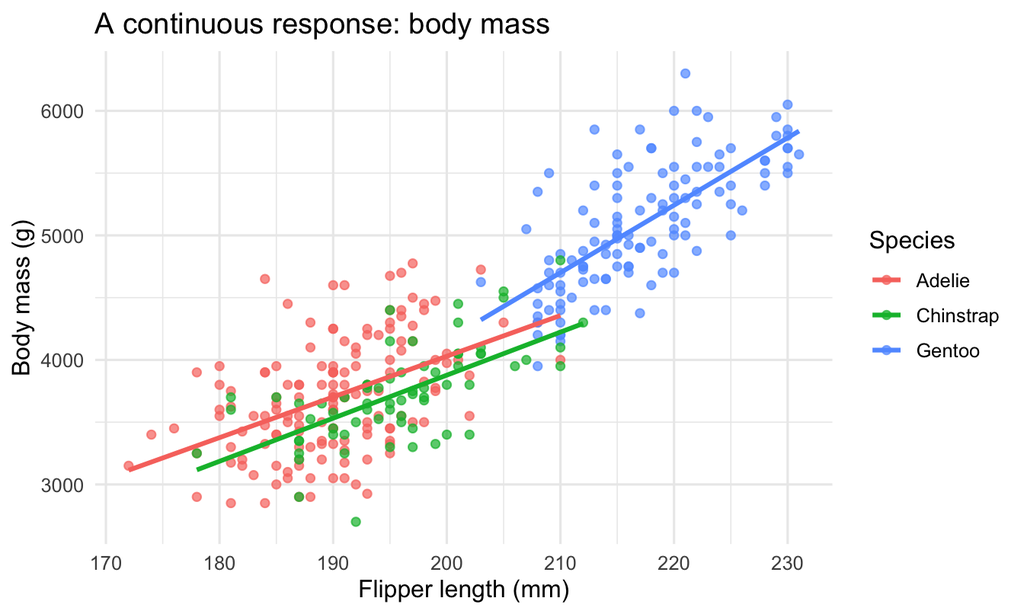

```r
ggplot(penguins_clean,
       aes(x = flipper_length_mm, y = body_mass_g, colour = species)) +
  geom_point(alpha = 0.7) +
  geom_smooth(method = "lm", se = FALSE) +
  labs(
    title = "A continuous response: body mass",
    x = "Flipper length (mm)",
    y = "Body mass (g)",
    colour = "Species"
  )
```

## 4.3 Fit `lm()` and `glm()`

```r
lm_fit <- lm(body_mass_g ~ flipper_length_mm + species,
             data = penguins_clean)

gaussian_glm <- glm(body_mass_g ~ flipper_length_mm + species,
                    family = gaussian(link = "identity"),
                    data = penguins_clean)

round(coef(lm_fit), 3)
```

```
##       (Intercept) flipper_length_mm  speciesChinstrap     speciesGentoo
##         -4013.179            40.606          -205.375           284.524
```

```r
round(coef(gaussian_glm), 3)
```

```
##       (Intercept) flipper_length_mm  speciesChinstrap     speciesGentoo
##         -4013.179            40.606          -205.375           284.524
```

The estimates are the same because `lm()` is a special case of a GLM.

## 4.4 Model summary

```r
summary(gaussian_glm)
```

```
##
## Call:
## glm(formula = body_mass_g ~ flipper_length_mm + species, family = gaussian(link = "identity"),
##     data = penguins_clean)
##
## Coefficients:
##                   Estimate Std. Error t value Pr(>|t|)
## (Intercept)       -4013.18     586.25  -6.846 3.74e-11 ***
## flipper_length_mm    40.61       3.08  13.186  < 2e-16 ***
## speciesChinstrap   -205.38      57.57  -3.568 0.000414 ***
## speciesGentoo       284.52      95.43   2.981 0.003083 **
## ---
## Signif. codes:  0 '***' 0.001 '**' 0.01 '*' 0.05 '.' 0.1 ' ' 1
##
## (Dispersion parameter for gaussian family taken to be 139340.9)
##
##     Null deviance: 215259666  on 332  degrees of freedom
## Residual deviance:  45843144  on 329  degrees of freedom
## AIC: 4895.3
##
## Number of Fisher Scoring iterations: 2
```

For Gaussian data, the residual deviance is the residual sum of squares. For non-Gaussian GLMs, deviance generalises this idea using likelihoods.

# 5 Interpreting GLM output

## 5.1 Coefficients and scales

GLM coefficients are estimated on the **link scale**.

For example:

- Logistic regression: coefficients are on the **log-odds** scale.
- Poisson regression: coefficients are on the **log-count** or **log-rate** scale.

To make interpretation easier, we often transform coefficients back to the response scale:

- Logistic: use `plogis()` for probabilities or `exp()` for odds ratios.
- Poisson: use `exp()` for multiplicative changes in expected counts or rates.

## 5.2 Prediction scales

```r
new_penguins <- tibble(
  flipper_length_mm = c(180, 200, 220),
  species = factor("Adelie", levels = levels(penguins_clean$species))
)

predict(gaussian_glm, newdata = new_penguins)                  # link scale
```

```
##        1        2        3
## 3295.931 4108.054 4920.177
```

```r
predict(gaussian_glm, newdata = new_penguins, type = "response") # response scale
```

```
##        1        2        3
## 3295.931 4108.054 4920.177
```

For a Gaussian identity-link model, these are the same. For logistic and Poisson models, they are different.

# 6 Model checking

## 6.1 Residual plots

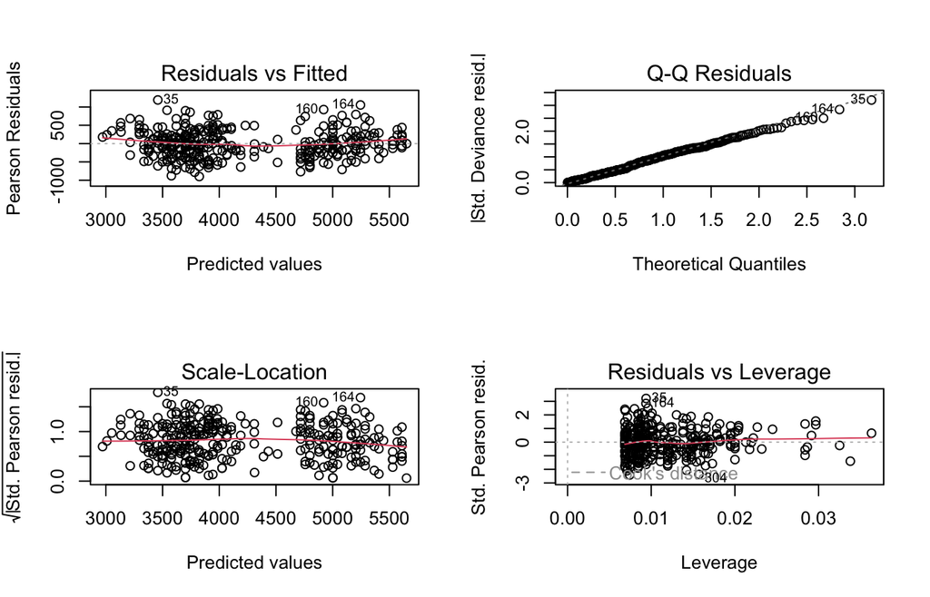

```r
par(mfrow = c(2, 2))
plot(gaussian_glm)
```

```r
par(mfrow = c(1, 1))
```

For non-Gaussian GLMs, the same plots are useful starting points, but they are not enough. We also check whether the assumed mean–variance relationship is plausible.

## 6.2 Key checks for GLMs

Ask:

1. Does the response match the chosen family?
2. Are the fitted values in a sensible range?
3. Are there influential observations?
4. For Poisson models, is there evidence of overdispersion?
5. Are predictions being interpreted on the correct scale?

# 7 Practical exercise

| Scientific question | Response | Suggested GLM family and link |
| --- | --- | --- |
| Does a site contain a species? | 0/1 presence |  |
| How many trees are in each plot? | Count |  |
| What is the mass of each animal? | Continuous |  |
| How many infected individuals out of 30? | Successes/trials |  |

```r
# 1. Add bill length as a predictor.
# 2. Compare the model with and without bill length using AIC().
# 3. Predict body mass for a new penguin with:
#    flipper_length_mm = 200, bill_length_mm = 45, species = "Gentoo".
```

## 7.3 Take-home messages

- GLMs extend linear models to non-Normal responses.
- The `family` argument defines the response distribution and link.
- Coefficients are usually on the link scale.
- Use `type = "response"` when you want fitted values or predictions in the original units.
- Always match the model family to the scientific response.